# Homework

### Individual Homework

#### Enter your name here:

## Santiago Andrés Sierra Ibáñez

```python
import pandas as pd
import matplotlib.pyplot as plt
import seaborn as sns
```

**Analysis of movies IMDB dataset**

We will look at a **subset** sample of movies, taken from the [Kaggle IMDB 5000 movie dataset](https://www.kaggle.com/carolzhangdc/imdb-5000-movie-dataset)

```python
movies = pd.read_csv('../Data/movies.csv')
movies
```

|  | title | genre | director | year | duration | gross | budget | cast_facebook_likes | votes | reviews | rating |
| --- | --- | --- | --- | --- | --- | --- | --- | --- | --- | --- | --- |
| 0 | Avatar | Action | James Cameron | 2009 | 178 | 760505847 | 237000000 | 4834 | 886204 | 3777 | 7.9 |
| 1 | Titanic | Drama | James Cameron | 1997 | 194 | 658672302 | 200000000 | 45223 | 793059 | 2843 | 7.7 |
| 2 | Jurassic World | Action | Colin Trevorrow | 2015 | 124 | 652177271 | 150000000 | 8458 | 418214 | 1934 | 7.0 |
| 3 | The Avengers | Action | Joss Whedon | 2012 | 173 | 623279547 | 220000000 | 87697 | 995415 | 2425 | 8.1 |
| 4 | The Dark Knight | Action | Christopher Nolan | 2008 | 152 | 533316061 | 185000000 | 57802 | 1676169 | 5312 | 9.0 |
| ... | ... | ... | ... | ... | ... | ... | ... | ... | ... | ... | ... |
| 2956 | Locker 13 | Thriller | Bruce Dellis | 2014 | 95 | 2468 | 300000 | 2048 | 241 | 15 | 4.8 |
| 2957 | The Ghastly Love of Johnny X | Comedy | Paul Bunnell | 2012 | 106 | 2436 | 2000000 | 1611 | 344 | 113 | 5.7 |
| 2958 | Detention of the Dead | Comedy | Alex Craig Mann | 2012 | 87 | 1332 | 500000 | 2251 | 2038 | 49 | 4.6 |
| 2959 | The Trials of Darryl Hunt | Crime | Ricki Stern | 2006 | 106 | 1111 | 200000 | 2 | 771 | 21 | 7.7 |
| 2960 | The Jimmy Show | Comedy | Frank Whaley | 2001 | 96 | 703 | 1500000 | 920 | 480 | 30 | 5.4 |

2961 rows × 11 columns

```python
movies.info()
```

```
<class 'pandas.core.frame.DataFrame'>
RangeIndex: 2961 entries, 0 to 2960
Data columns (total 11 columns):
 #   Column               Non-Null Count  Dtype
---  ------               --------------  -----
 0   title                2961 non-null   object
 1   genre                2961 non-null   object
 2   director             2961 non-null   object
 3   year                 2961 non-null   int64
 4   duration             2961 non-null   int64
 5   gross                2961 non-null   int64
 6   budget               2961 non-null   int64
 7   cast_facebook_likes  2961 non-null   int64
 8   votes                2961 non-null   int64
 9   reviews              2961 non-null   int64
 10  rating               2961 non-null   float64
dtypes: float64(1), int64(7), object(3)
memory usage: 254.6+ KB
```

```python
movies.describe()
```

|  | year | duration | gross | budget | cast_facebook_likes | votes | reviews | rating |
| --- | --- | --- | --- | --- | --- | --- | --- | --- |
| count | 2961.000000 | 2961.00000 | 2.961000e+03 | 2.961000e+03 | 2961.000000 | 2.961000e+03 | 2961.000000 | 2961.000000 |
| mean | 2002.901385 | 109.64539 | 5.809040e+07 | 4.061938e+07 | 12393.760892 | 1.093075e+05 | 503.305302 | 6.389227 |
| std | 9.946227 | 22.17132 | 7.246962e+07 | 4.368201e+07 | 20530.107207 | 1.581439e+05 | 493.736710 | 1.051625 |
| min | 1920.000000 | 37.00000 | 7.030000e+02 | 2.180000e+02 | 0.000000 | 5.000000e+00 | 2.000000 | 1.600000 |
| 25% | 1999.000000 | 95.00000 | 1.227681e+07 | 1.100000e+07 | 2241.000000 | 1.991800e+04 | 199.000000 | 5.800000 |
| 50% | 2004.000000 | 106.00000 | 3.470323e+07 | 2.600000e+07 | 4604.000000 | 5.574900e+04 | 364.000000 | 6.500000 |
| 75% | 2010.000000 | 119.00000 | 7.559029e+07 | 5.500000e+07 | 16926.000000 | 1.333480e+05 | 631.000000 | 7.100000 |
| max | 2016.000000 | 330.00000 | 7.605058e+08 | 3.000000e+08 | 656730.000000 | 1.689764e+06 | 5312.000000 | 9.300000 |

Besides the obvious variables of `title`, `genre`, `director`, `year`, and `duration`, the rest of the variables are as follows:

- `gross` : The gross earnings in the US box office, not adjusted for inflation
- `budget`: The movie's budget
- `cast_facebook_likes`: the number of facebook likes cast memebrs received
- `votes`: the number of people who voted for (or rated) the movie in IMDB
- `reviews`: the number of reviews for that movie
- `rating`: IMDB average rating

**Produce a table with the count of movies by genre, ranked in descending order**

```python
movies_by_genre = (movies
                    .groupby("genre")
                    .agg(
                        count = ("genre","count")
                    )
                    .sort_values(by="count", ascending=False)
                )
movies_by_genre
```

| genre | count |
| --- | --- |
| Comedy | 848 |
| Action | 738 |
| Drama | 498 |
| Adventure | 288 |
| Crime | 202 |
| Biography | 135 |
| Horror | 131 |
| Animation | 35 |
| Fantasy | 28 |
| Documentary | 25 |
| Mystery | 16 |
| Sci-Fi | 7 |
| Family | 3 |
| Romance | 2 |
| Musical | 2 |
| Western | 2 |
| Thriller | 1 |

```python
movies.genre.value_counts()
```

```
genre
Comedy         848
Action         738
Drama          498
Adventure      288
Crime          202
Biography      135
Horror         131
Animation       35
Fantasy         28
Documentary     25
Mystery         16
Sci-Fi           7
Family           3
Musical          2
Romance          2
Western          2
Thriller         1
Name: count, dtype: int64
```

**Produce a table with the average gross earning and budget (`gross` and `budget`) by genre. Calculate a variable `return_on_budget` which shows how many $ did a movie make at the box office for each $ of its budget. Ranked genres by this `return_on_budget` in descending order**

```python
avg_gross_earning_by_genre = (movies
                                .assign(
                                    return_on_budget = movies["gross"] / movies["budget"]
                                )
                                .groupby("genre", dropna=False)
                                .agg(
                                    average_gross_earnings = ("gross","mean"),
                                    average_budget = ("budget","mean"),
                                    average_return_on_budget = ("return_on_budget","mean")
                                )
                                .reset_index()
                                .sort_values(by="average_return_on_budget", ascending=False)
                            )

avg_gross_earning_by_genre
```

|  | genre | average_gross_earnings | average_budget | average_return_on_budget |
| --- | --- | --- | --- | --- |
| 10 | Horror | 3.771374e+07 | 1.350492e+07 | 88.304785 |
| 3 | Biography | 4.520181e+07 | 2.854370e+07 | 22.280597 |
| 11 | Musical | 9.208400e+07 | 3.189500e+06 | 18.817819 |
| 8 | Family | 1.491605e+08 | 1.483333e+07 | 14.076490 |
| 6 | Documentary | 1.735397e+07 | 5.887852e+06 | 8.698550 |
| 16 | Western | 2.082188e+07 | 3.465000e+06 | 7.062800 |
| 9 | Fantasy | 4.240884e+07 | 1.758214e+07 | 6.681969 |
| 2 | Animation | 9.843379e+07 | 6.170143e+07 | 5.009095 |
| 4 | Comedy | 4.263055e+07 | 2.444632e+07 | 3.713990 |
| 12 | Mystery | 6.753302e+07 | 3.921875e+07 | 3.269397 |
| 13 | Romance | 3.126485e+07 | 2.510750e+07 | 3.168112 |
| 7 | Drama | 3.746537e+07 | 2.624293e+07 | 2.946105 |
| 1 | Adventure | 9.579426e+07 | 6.629007e+07 | 2.411706 |
| 5 | Crime | 3.750240e+07 | 2.659617e+07 | 2.174751 |
| 0 | Action | 8.658386e+07 | 7.135489e+07 | 1.920877 |
| 14 | Sci-Fi | 2.978837e+07 | 2.760714e+07 | 1.580394 |
| 15 | Thriller | 2.468000e+03 | 3.000000e+05 | 0.008227 |

**Produce a table that shows the top 15 directors who have created the highest gross revenue in the box office. Don't just show the total gross amount, but also the mean, median, and standard deviation per director**

```python
top_15_directors = (movies
                    .groupby("director", dropna=False)
                    .agg(
                        total_revenue = ("gross","sum"),
                        avg_revenue = ("gross","mean"),
                        median_revenue = ("gross","median"),
                        std_revenue = ("gross","std")
                    )
                    .sort_values(by="total_revenue", ascending=False)
                )

top_15_directors.head(15)
```

| director | total_revenue | avg_revenue | median_revenue | std_revenue |
| --- | --- | --- | --- | --- |
| Steven Spielberg | 4014061704 | 1.745244e+08 | 164435221.0 | 1.014211e+08 |
| Michael Bay | 2231242537 | 1.716340e+08 | 138396624.0 | 1.271616e+08 |
| Tim Burton | 2071275480 | 1.294547e+08 | 76519172.0 | 1.087269e+08 |
| Sam Raimi | 2014600898 | 2.014601e+08 | 234903076.0 | 1.621266e+08 |
| James Cameron | 1909725910 | 3.182877e+08 | 175562880.5 | 3.091713e+08 |
| Christopher Nolan | 1813227576 | 2.266534e+08 | 196667606.5 | 1.872241e+08 |
| George Lucas | 1741418480 | 3.482837e+08 | 380262555.0 | 1.461939e+08 |
| Robert Zemeckis | 1619309108 | 1.245622e+08 | 100853835.0 | 9.130028e+07 |
| Clint Eastwood | 1378321100 | 7.254322e+07 | 46700000.0 | 7.548741e+07 |
| Francis Lawrence | 1358501971 | 2.717004e+08 | 281666058.0 | 1.354370e+08 |
| Ron Howard | 1335988092 | 1.113323e+08 | 101587923.0 | 8.193376e+07 |
| Gore Verbinski | 1329600995 | 1.899430e+08 | 123207194.0 | 1.544738e+08 |
| Andrew Adamson | 1137446920 | 2.843617e+08 | 279680930.5 | 1.208958e+08 |
| Shawn Levy | 1129750988 | 1.027046e+08 | 85463309.0 | 6.548477e+07 |
| Ridley Scott | 1128857598 | 8.063269e+07 | 47775715.0 | 6.881228e+07 |

**Produce a table that describes how ratings are distributed by genre. We don't want just the mean, but also, min, max, median, SD and some kind of a histogram or density graph that visually shows how ratings are distributed.**

```python
rating_by_genre = (movies
                    .groupby("genre", dropna=False)
                    .agg(
                        mean_rating = ("rating","mean"),
                        min_rating = ("rating","min"),
                        max_rating = ("rating","max"),
                        median_rating = ("rating","median"),
                        std_rating = ("rating","std"),
                    )
)

rating_by_genre
```

| genre | mean_rating | min_rating | max_rating | median_rating | std_rating |
| --- | --- | --- | --- | --- | --- |
| Action | 6.232249 | 2.1 | 9.0 | 6.30 | 1.030362 |
| Adventure | 6.506597 | 2.3 | 8.6 | 6.60 | 1.093881 |
| Animation | 6.651429 | 4.5 | 8.0 | 6.90 | 0.968131 |
| Biography | 7.114074 | 4.5 | 8.9 | 7.20 | 0.759827 |
| Comedy | 6.109670 | 1.9 | 8.8 | 6.20 | 1.023075 |
| Crime | 6.915347 | 4.8 | 9.3 | 6.90 | 0.849356 |
| Documentary | 6.660000 | 1.6 | 8.5 | 7.40 | 1.766588 |
| Drama | 6.731526 | 2.1 | 8.8 | 6.80 | 0.916993 |
| Family | 6.500000 | 5.7 | 7.9 | 5.90 | 1.216553 |
| Fantasy | 6.153571 | 4.3 | 7.9 | 6.45 | 0.958966 |
| Horror | 5.833588 | 3.6 | 8.5 | 5.90 | 1.014329 |
| Musical | 6.750000 | 6.3 | 7.2 | 6.75 | 0.636396 |
| Mystery | 6.856250 | 4.6 | 8.5 | 6.90 | 0.881641 |
| Romance | 6.650000 | 6.2 | 7.1 | 6.65 | 0.636396 |
| Sci-Fi | 6.657143 | 5.0 | 8.2 | 6.40 | 1.093705 |
| Thriller | 4.800000 | 4.8 | 4.8 | 4.80 | NaN |
| Western | 5.700000 | 4.1 | 7.3 | 5.70 | 2.262742 |

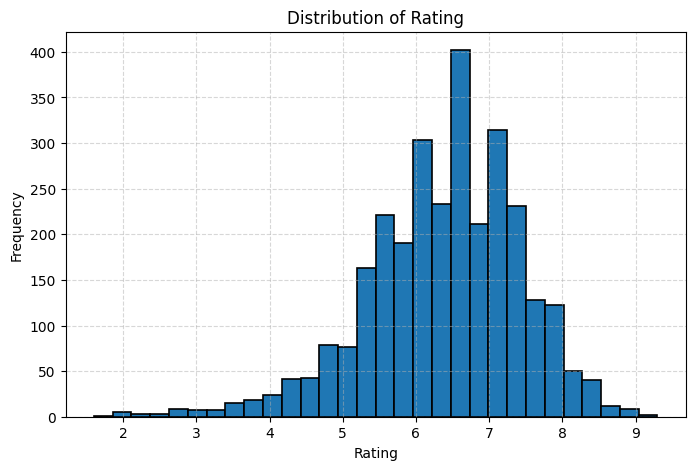

```python
# help (plt.hist)
plt.figure(figsize=(8,5))
plt.hist(x=movies["rating"], bins=30, edgecolor='black', linewidth=1.2)
plt.title("Distribution of Rating")
plt.xlabel("Rating")
plt.ylabel("Frequency")
plt.grid(True, linestyle="--", alpha=0.5)
plt.show()
plt.show()
```

**Challenge - Produce a table of your own choosing, something you think is important/interesting to have data for, justify your result by writting a 2 sentence explanation/interpretation of the result.**

```python
own_table = (movies
                .groupby("director", dropna=False)
                .agg(
                    avg_votes = ("votes","mean"),
                    min_votes = ("votes","min"),
                    max_votes = ("votes","max"),
                    median_votes = ("votes","median"),
                    std_votes = ("votes","std"),
                    count_movies = ("title","size")
                )
                .sort_values(by="avg_votes", ascending=False)
                .reset_index()
)

own_table.head(10)
```

|  | director | avg_votes | min_votes | max_votes | median_votes | std_votes | count_movies |
| --- | --- | --- | --- | --- | --- | --- | --- |
| 0 | Christopher Nolan | 1.013285e+06 | 218771 | 1676169 | 954586.5 | 440751.862030 | 8 |
| 1 | Irvin Kershner | 8.377590e+05 | 837759 | 837759 | 837759.0 | NaN | 1 |
| 2 | Tony Kaye | 7.824370e+05 | 782437 | 782437 | 782437.0 | NaN | 1 |
| 3 | Quentin Tarantino | 6.988325e+05 | 239540 | 1324680 | 700251.5 | 362864.764457 | 8 |
| 4 | Frank Darabont | 6.844700e+05 | 45031 | 1689764 | 501542.5 | 740365.018258 | 4 |
| 5 | Richard Marquand | 6.818570e+05 | 681857 | 681857 | 681857.0 | NaN | 1 |
| 6 | Peter Jackson | 6.099854e+05 | 125109 | 1215718 | 483540.0 | 522890.385227 | 5 |
| 7 | Joss Whedon | 5.668943e+05 | 242599 | 995415 | 462669.0 | 387079.026228 | 3 |
| 8 | Lee Unkrich | 5.448840e+05 | 544884 | 544884 | 544884.0 | NaN | 1 |
| 9 | Andrew Stanton | 5.411743e+05 | 212204 | 718837 | 692482.0 | 285201.256425 | 3 |

#### Importance:

I produced a table to check how directors performed in the dataset in terms of votes. Analizing the mean, min, mix, median, standard deviation and number of movies. I think it's important to analyze such information so we can have a sense of how much were directors voted taking into account the number of movies they did.

#### Analysis:

1. Christopher nolan had the most average votes, with around 200k difference with the second-most voted director, Irvin Kershner
2. Nevertheless, it's interesting to see that Irvin got this amount of votes with only one movie, same as per third, sixth and ninth most voted ones. Nolan, even if first, got it by producing 8 movies.

#### Use visualisation to answer the following questions

**Examine the relationship between `gross` and `cast_facebook_likes`. Produce a scatterplot and write one sentence discussing whether the number of facebook likes that the cast has received is likely to be a good predictor of how much money a movie will make at the box office. What variable are you going to map to the Y- and X- axes?**

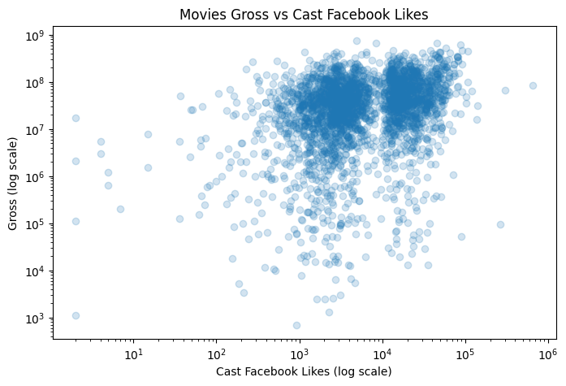

```python
# Scatter plots of movies gross vs cast_facebook_likes

plt.figure(figsize=(8,5))
plt.scatter(data=movies, x="cast_facebook_likes", y="gross", alpha=0.2)
plt.xscale("log")
plt.yscale("log")
plt.xlabel("Cast Facebook Likes (log scale)")
plt.ylabel("Gross (log scale)")
plt.title("Movies Gross vs Cast Facebook Likes")
plt.show()
```

#### A/

I believe there's a wide spread of data, and while higher-grossing movies often have casts with higher Facebook likes, the relationship isn’t very tight.

**Examine the relationship between `gross` and `budget`. Produce a scatterplot and write one sentence discussing whether budget is likely to be a good predictor of how much money a movie will make at the box office.**

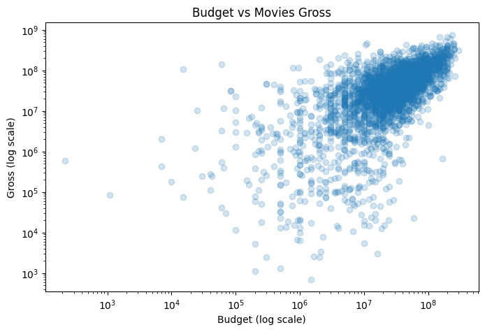

```python
# Scatter plots of movies gross vs budget


plt.figure(figsize=(8,5))
plt.scatter(data=movies, x="budget", y="gross", alpha=0.2)
plt.xscale("log")
plt.yscale("log")
plt.xlabel("Budget (log scale)")
plt.ylabel("Gross (log scale)")
plt.title("Budget vs Movies Gross")
plt.show()
```

#### A/

Judging by the visualization, I believe there seems to be a positive correlation between Gross and Budget, meaning budget is likely to be a good predictor of how much money a movie will make at the box office.

**Examine the relationship between `gross` and `rating`. Produce a scatterplot, faceted by `genre` and discuss whether IMDB ratings are likely to be a good predictor of how much money a movie will make at the box office. Is there anything strange in this dataset?**

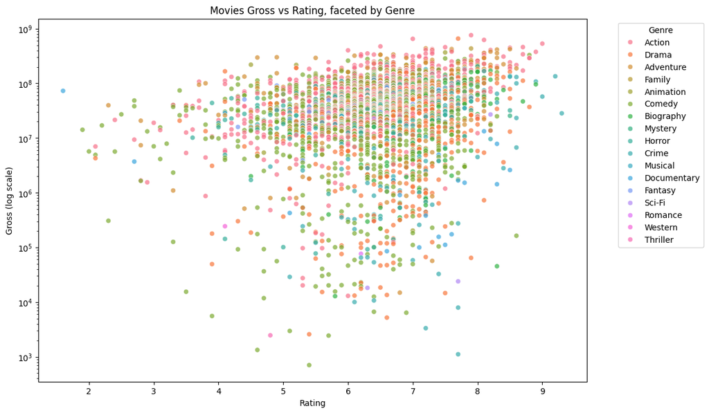

```python
# Scatter plot of movies gross vs rating, faceted by genre

plt.figure(figsize=(12,8))
sns.scatterplot(data=movies, x="rating", y="gross", hue="genre", alpha=0.7)
plt.yscale("log")
plt.xlabel("Rating")
plt.ylabel("Gross (log scale)")
plt.title("Movies Gross vs Rating, faceted by Genre")
plt.legend(title="Genre", bbox_to_anchor=(1.05, 1), loc='upper left')
plt.show()
```

**Challenge - Produce a visualisation of your choosing, something you think is important to explore/investigate visually. Do make it a comprehensive graph and not a single histogram or density plot. Make it publication ready, label your axes, give it a title, choose colouring options, appropirately formatted text etc.**

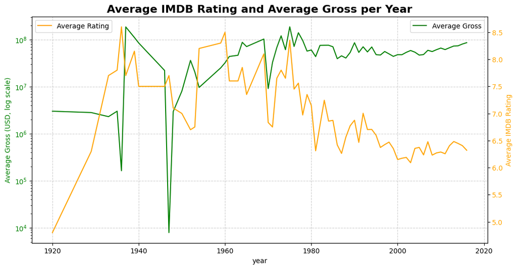

```python
# Average IMDB Rating and Average Gross per Year
# Group by year
average_stats = (
    movies.groupby("year")
    .agg(
        average_rating=("rating", "mean"),
        average_gross=("gross", "mean"),
        count=("title", "size")
    )
    .reset_index()
)

# Plot with dual axes
fig, ax1 = plt.subplots(figsize=(12,6))

# Average Gross (log scale)
sns.lineplot(data=average_stats, x="year", y="average_gross", ax=ax1, color="green", label="Average Gross")
ax1.set_yscale("log")
ax1.set_ylabel("Average Gross (USD, log scale)", color="green")
ax1.tick_params(axis='y', labelcolor="green")

# Second y-axis for Ratings
ax2 = ax1.twinx()
sns.lineplot(data=average_stats, x="year", y="average_rating", ax=ax2, color="orange", label="Average Rating")
ax2.set_ylabel("Average IMDB Rating", color="orange")
ax2.tick_params(axis='y', labelcolor="orange")

# Titles and aesthetics
plt.title("Average IMDB Rating and Average Gross per Year", fontsize=16, weight="bold")
ax1.grid(True, linestyle="--", alpha=0.6)
ax2.legend(loc="upper left")


plt.show()
```

### Deliverables

Poduce a clean, stand-alone notebook (or HTML export) with:

All tables/plots properly labeled

Brief interpretations where requested

Upload final HTML/Notebook.